# IRIS-CEM vignette

IRIS-CEM

Yuzhou Chang

12 Aug, 2020

#### Abstract

IRIS-CEM integrates in-house and state-of-the-art computational tools and provides two analysis strategies, including LTMG (left-truncated mixture Gaussian model)-embedded scRNA-Seq analy-sis and co-expression gene analysis.

# Intorduction to IRIS-CEM

## General introduction

IRIS-CEM integrates in-house and state-of-the-art computational tools and provides two analysis strategies, including bicluster-based co-expression gene analysis [(Xie, et al., 2020)](https://academic.oup.com/bioinformatics/article-abstract/36/4/1143/5567116?redirectedFrom=fulltext) and LTMG (left-truncated mixture Gaussian model)-embedded scRNA-Seq analysis [(Wan, et al., 2019)](https://academic.oup.com/nar/article/47/18/e111/5542876).

## Main function

The main idea of IRIS-CEM consists of two major strategies:

- 1. biclustering
- 2. quick mode (cluster)

## Obejct structure

The computational frame is constructed under the S4 data structure in R. The structure of `IRISCEM object` is:

- -**IRISCEM_Object:** *name of object is called IRISCEM.*
  - -**raw_count:** *raw data matrix (gene in row, cell in columns, prefer using gene symbol).*
  - -**processed_count:** *normalized and imputation (default: FALSE).*
  - -**Meta_info:** *cell classification information based on LTMG and Bicluster.*
  - -**Discretization:** *discretized matrix based on qubic 1.0, which prepares for microarry and bulk RNA-Seq analysis.*
  - -**LTMG:** *LTMG slot is for storing relative results from first strategy.*
    - -**LTMG_discrete:** *Condition assigned matrix, which is generating from LTMG model.*
    - -**LTMG_BinarySingleSignal:** *binary matrix based on gene “on /off.”*
    - -**LTMG_BinaryMultisignal:** *binary matrix based on multiple condition.*
    - -**DimReduce:** *include three dimension loading score, including PCA, Tsne, and UMAP*
    - -**MarkerGene:** *Marker gene based on cell type identified by Seurat clustering method.*
    - -**Pathway:** *based on marker gene.*
    - -**tmp.Seurat:** *temporary Seurat object. In this Seurat Object, the starting matrix is LTMG signalling matrix.*
  - -**Bicluster:** **
    - -**Coreg_gene:** *co-regulatory genes are stored in this slot as dataframe; the first column is gene name and the second column is module number.*
    - -**CoCond_cell:** *co-condition cell are stored in this slot as dataframe; the first column is cell name and the second column is module number.*
    - -**MarkerGene:** *Marker gene based on cell type identified by Markov chain clustering algorithm.*
    - -**Pathway:** *genes based on co-expression gene of gene module (from Coreg_gene).*

# Requirements

## Environment

We recommend user to install IRIS-CEM on large memory (32GB) based linux operation system if user aims at analyzing bicluster-based co-expression analysis; if user aims at analyzing data by quick mode, we recommend to install IRIS-CEM on small memeory (8GB) based Windows or linux operation system; IRIS-CEM does not support MAC. We will assum you have the following installed:

- R (equal or greater than 3.5)

Pre-install packge

```r
install.packages(c('BiocManager','devtools', 'AdaptGauss', "pheatmap", 'mixtools','MCL', 'anocva',
                   'qgraph','Rtools','ggpubr',"ggraph"))
BiocManager::install(c('org.Mm.eg.db','multtest', 'org.Hs.eg.db','clusterProfiler','DEsingle',
                       'DrImpute', 'scater', 'scran'))
devtools::install_github(repo = 'satijalab/seurat')
```

## Input

1. The input to IRIS-CEM is the single-cell RNA-seq expression matrix:
- Rows correspond to genes and columns correspond to cells.
- Expression units: the preferred expression values are RPKM/FPKM/CPM.
- The data file should be tab delimited.
2. IRIS-CEM also accept output files from 10X CellRanger, includinhg a folder which contains three individual files and h5 file.

## Others

When you perform co-expression analysis, it will output several intermediate files, thus please make sure that you have write permission to the folder where IRIS-CEM is located.

# Installation

# Example dataset

This tutorial run on a real dataset to illustrate the results obtained at each step.

As example, we will use Yan’s data, a dataset containing 90 cells and 20,214 genes from human embryo, to conduct cell type prediction.

> Yan, L. et al. Single-cell RNA-Seq profiling of human preimplantation embryos and embryonic stem cells. Nat. Struct. Mol. Biol. 20, 1131-1139 (2013)

The original expression matrix was downloaded from https://s3.amazonaws.com/scrnaseq-public-datasets/manual-data/yan/nsmb.2660-S2.csv. The expression is provided as RPKM value. For convenience, we removed the space in the column names and deleted the second column(Transcript_ID). The processed data is available at https://github.com/zy26/BRICdata/blob/master/Example%20data/Yan_RPKM.

# 1. Input data, create IRISCEM object, add meta information, and preprocessing.

IRIS-CEM can accepted 10X chromium input files, including a folder (contain gene name, cell name, and sparse matrix) and .h5 file.

## Input data

1. set working directory and import library

```r
setwd("~/2.Yan/")
library(IRISCEM)
```

2. Read from .h5 file.

```r
InputMatrix <- ReadFrom10X_h5("~/5k_pbmc_protein_v3_filtered_feature_bc_matrix.h5")
```

3. Read from 10X folder.

```r
InputMatrix <- ReadFrom10X_folder("~/10X_3K/folder_10X/")
```

4. Read from .csv or .txt file

we will use this data set as example to run the pipeline.

```r
InputMatrix <- read.table("~/2.Yan/Yan_expression.txt",header = T, row.names = 1)
```

## Add meta information

1. Create IRIS-CEM object.

```r
object <- CreateIRISCEMObject(InputMatrix)
```

2. Addmeta: this step can add customized cell label by user, the format of file passing to `meta.info` is data frame of which row name should be cell ID, and column name should be cell type.

```r
object <- AddMeta(object, meta.info = NULL)
```

3. plotmeta: plot meta information based on RNA count and Feature number. This step is for the following subset step in terms of filtering out low quality data.

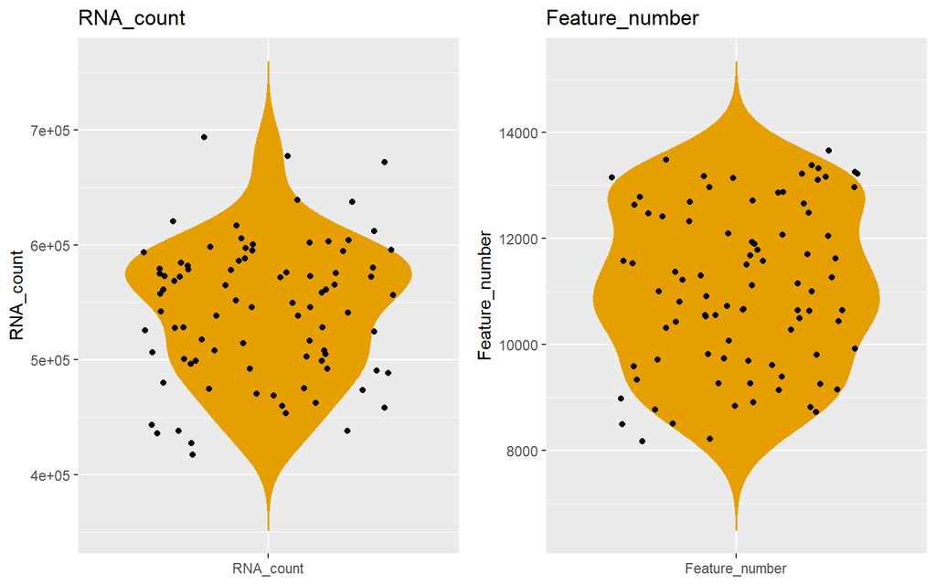

```r
PlotMeta(object)
```

4. remove low quality data based on the previous plot.

```r
object <- SubsetData(object , nFeature.upper=15000,nFeature.lower=8000,
                         Counts.upper=700000,Counts.lower=400000)
```

## Preprocesing

User can choose perform normalization or imputation based on their need. The normalization method has two options, one is the simplist CPM normalization (default `normalization = 'LibrarySizeNormalization'`). The other is from package scran and can be opened by using parameter `normalization = 'scran'`, . The imputation method is from package DrImpute and can be opened by using parameter `IsImputation = TRUE` (default as closed).

```r
object <- ProcessData(object, normalization = "LibrarySizeNormalization", IsImputation = FALSE, seed = 123)
```

# 2. Run LTMG

The argument `Gene_use = 500` is top 500 highlt variant genes which are selected to run LTMG. For quick mode, we recommend to use top 2000 gene (here we use top 500 gene for saving time). On the contrary, for co-expression gene analysis, we recommend to use all gene by changing `Gene_use = "all"`.

```r
# demo only run top 500 gene for saving time.
object <- RunLTMG(object, Gene_use = 500, seed = 123)
```

# 3. Seurat implemented analysis.

## Dimension Reduction

User can use `reduction = "umap"` or `reductopm = "tsne"` to perform dimension reduction.

```r
# demo only run top 500 gene for saving time.
object <- RunDimensionReduction(object, reduction = "umap")
```

## Cluster

```r
# demo only run top 500 gene for saving time.
object <- RunClassification(object,  k.param = 20, resolution = 0.5, algorithm = 1)
```

## Plot dimension reduction plot

```r
# demo only run top 500 gene for saving time.
PlotDimension(object,reduction = "umap")
```

This function need user to input group that is used to plot on the figure. Input `4` means choose the “Seurat0.5” group as cell label to plot.

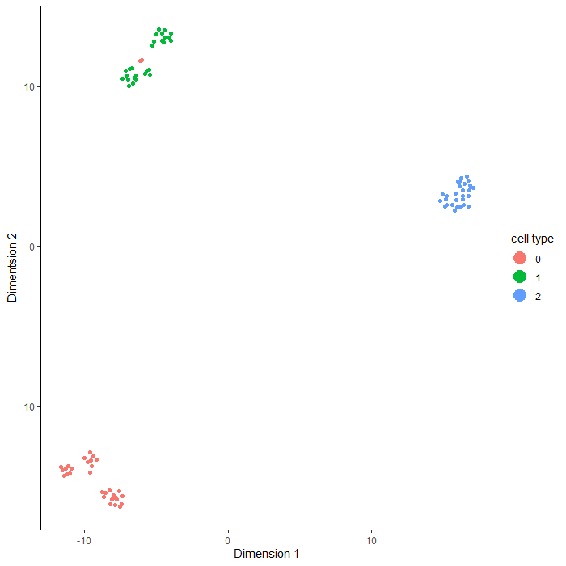

# 4. Biclustering based co-expression analysis

## LTMG-discretized bicluster (recommend for small single cell RNA-seq data)

User can type the following command to run discretization (LTMG) + biclustering directly:

```r
object <- RunLTMG(object, Gene_use = "all", seed = 123)
object <- CalBinaryMultiSignal(object)
object <- RunBicluster(object, DiscretizationModel = "LTMG",OpenDual = TRUE,
                          NumBlockOutput = 100, BlockOverlap = 0.7, BlockCellMin = 15)
```

## Quantile-discretized bicluster (recommend for bulk RNA-Seq, microarray data, or large single cell RNA-Seq data)

This will output several files, and among them you will find one named `Yan_sub.txt.chars.blocks`,which contains the predicted biclusters. Or, user may use first version discretization strategy provided by QUBIC 1.0.

```r
object <- RunDiscretization(object)
object <- RunBicluster(object, DiscretizationModel = "Quantile",OpenDual = TRUE, Extension = 0.90,
                          NumBlockOutput = 1000, BlockOverlap = 0.7, BlockCellMin = 15)
```

(The default parameters in IRIS-CEM are BlockCellMin=15, BlockOverlap=0.7, Extension=0.90, NumBlockOutput=100 you may use other parameters as you like, just specify them in the argument)

## Cell type prediction based on Markove clustering

```r
object <- FindClassBasedOnMC(object)
```

## Visualize block and network.

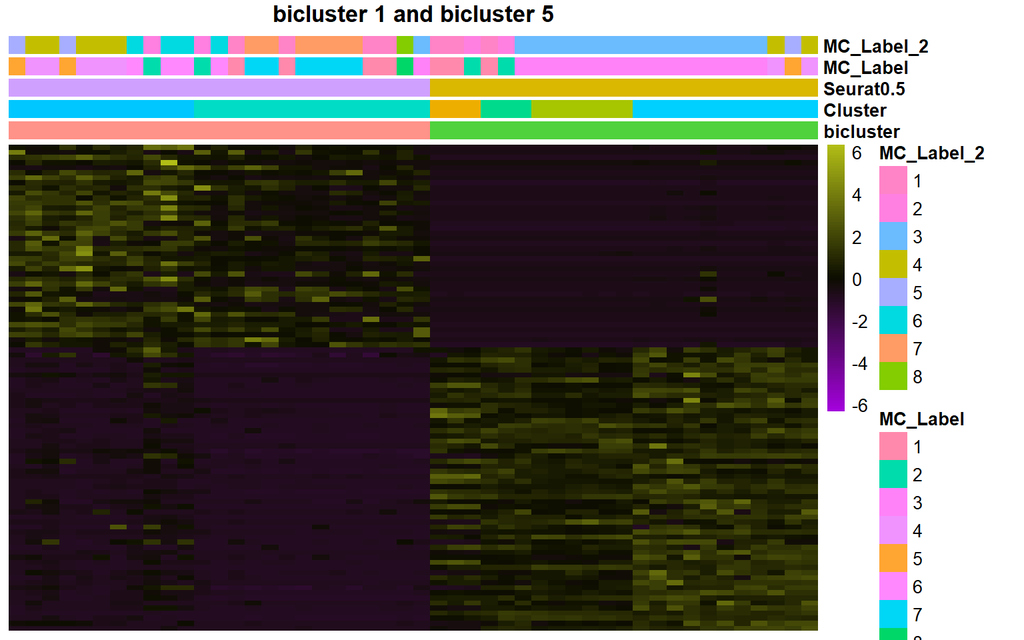

```r
PlotHeatmap(object ,N.bicluster =c(1,5),show.annotation = T)
```

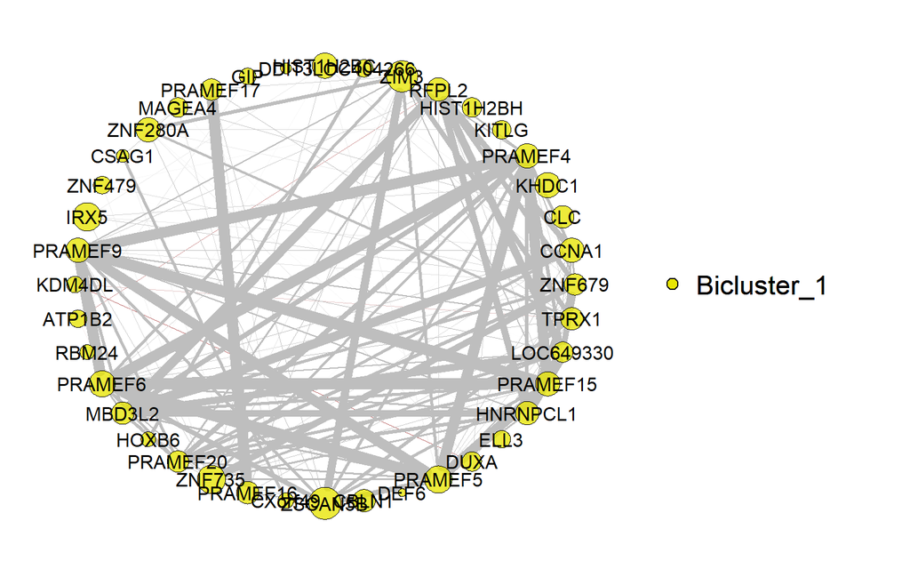

```r
PlotModuleNetwork(object, N.bicluster = 1, Node.color = "#E8E504")
```

# 5. Biological interpretation.

## Cell-type-specific marker genes

```r
object <- FindMarkers(object)
```

User need to select cell type to compare, while here we select `4:Suerat0.5` as cell type category to analyze.

Then IRIS-CEM will ask user choose a first group as reference, while here we select the third group (`3 : 2`) marked as cluster 2 in umap.

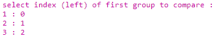

Then user requires to select the second group as compared object, while here user can choose either one group (`2 : 1`, `3 : 2`), or rest of all groups (`4 : rest of all`).

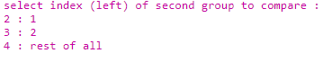

After running the `Findmarker`, user can find table in `object@LTMG@MarkerGene` if using quick mode or find table in `object@BiCluster@MarkerGene`.

## Cell-type-specific pathways.

The first pathway analysis is based on quick mode by specifying `genes.source = "CTS"`, which means cell-type-specific marker genes; the second pathway analysis is based on genes from bicluster block.

```r
object <- RunPathway(object, selected.gene.cutoff = 0.05,
                        species = "Human", database = "GO", genes.source = "CTS")
object <- RunPathway(object ,module.number = 5, selected.gene.cutoff = 0.05,
                        species = "Human", database = "GO", genes.source = "Bicluster")
```